# W3cubDocs

/scikit-learn

# sklearn.linear_model.LinearRegression

**`class sklearn.linear_model.LinearRegression(fit_intercept=True, normalize=False, copy_X=True, n_jobs=None)` [[source]](https://github.com/scikit-learn/scikit-learn/blob/bac89c2/sklearn/linear_model/base.py#L362)**

Ordinary least squares Linear Regression.

[output not shown]

#### Notes

From the implementation point of view, this is just plain Ordinary Least Squares (scipy.linalg.lstsq) wrapped as a predictor object.

#### Examples

```
>>> import numpy as np
>>> from sklearn.linear_model import LinearRegression
>>> X = np.array([[1, 1], [1, 2], [2, 2], [2, 3]])
>>> # y = 1 * x_0 + 2 * x_1 + 3
>>> y = np.dot(X, np.array([1, 2])) + 3
>>> reg = LinearRegression().fit(X, y)
>>> reg.score(X, y)
1.0
>>> reg.coef_
array([1., 2.])
>>> reg.intercept_
3.0000...
>>> reg.predict(np.array([[3, 5]]))
array([16.])
```

#### Methods

| `fit`(X, y[, sample_weight]) | Fit linear model. |
| --- | --- |
| `get_params`([deep]) | Get parameters for this estimator. |
| `predict`(X) | Predict using the linear model |
| `score`(X, y[, sample_weight]) | Returns the coefficient of determination R^2 of the prediction. |
| `set_params`(**params) | Set the parameters of this estimator. |

**`__init__(fit_intercept=True, normalize=False, copy_X=True, n_jobs=None)` [[source]](https://github.com/scikit-learn/scikit-learn/blob/bac89c2/sklearn/linear_model/base.py#L426)**

**`fit(X, y, sample_weight=None)` [[source]](https://github.com/scikit-learn/scikit-learn/blob/bac89c2/sklearn/linear_model/base.py#L433)**

Fit linear model.

[output not shown]

**`get_params(deep=True)` [[source]](https://github.com/scikit-learn/scikit-learn/blob/bac89c2/sklearn/base.py#L166)**

Get parameters for this estimator.

| Parameters: | **`deep : boolean, optional`** If True, will return the parameters for this estimator and contained subobjects that are estimators. |
| --- | --- |
| Returns: | **`params : mapping of string to any`** Parameter names mapped to their values. |

**`predict(X)` [[source]](https://github.com/scikit-learn/scikit-learn/blob/bac89c2/sklearn/linear_model/base.py#L200)**

Predict using the linear model

| Parameters: | **`X : array_like or sparse matrix, shape (n_samples, n_features)`** Samples. |
| --- | --- |
| Returns: | **`C : array, shape (n_samples,)`** Returns predicted values. |

**`score(X, y, sample_weight=None)` [[source]](https://github.com/scikit-learn/scikit-learn/blob/bac89c2/sklearn/base.py#L296)**

Returns the coefficient of determination R^2 of the prediction.

The coefficient R^2 is defined as (1 - u/v), where u is the residual sum of squares ((y_true - y_pred) ** 2).sum() and v is the total sum of squares ((y_true - y_true.mean()) ** 2).sum(). The best possible score is 1.0 and it can be negative (because the model can be arbitrarily worse). A constant model that always predicts the expected value of y, disregarding the input features, would get a R^2 score of 0.0.

[output not shown]

**`set_params(**params)` [[source]](https://github.com/scikit-learn/scikit-learn/blob/bac89c2/sklearn/base.py#L189)**

Set the parameters of this estimator.

The method works on simple estimators as well as on nested objects (such as pipelines). The latter have parameters of the form `<component>__<parameter>` so that it’s possible to update each component of a nested object.

| Returns: | **self** |
| --- | --- |

## Examples using `sklearn.linear_model.LinearRegression`

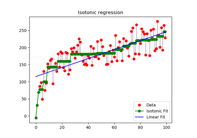

Isotonic Regression

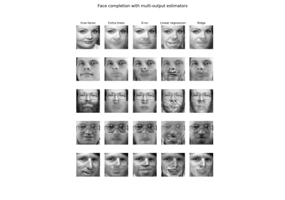

Face completion with a multi-output estimators

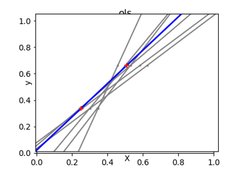

Ordinary Least Squares and Ridge Regression Variance

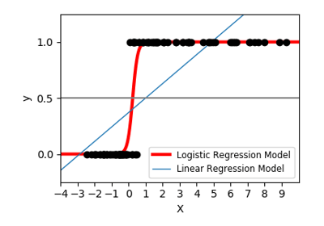

Logistic function

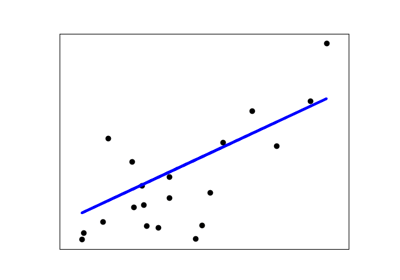

Linear Regression Example

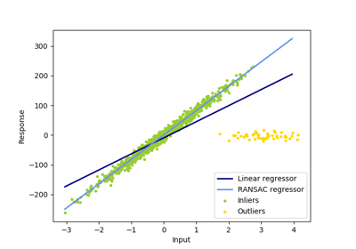

Robust linear model estimation using RANSAC

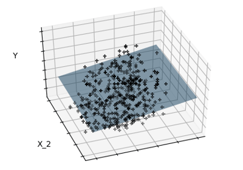

Sparsity Example: Fitting only features 1 and 2

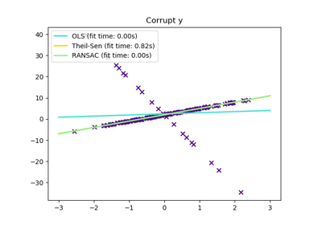

Theil-Sen Regression

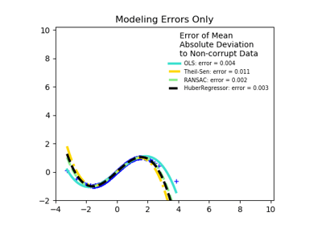

Robust linear estimator fitting

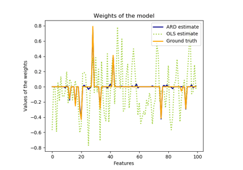

Automatic Relevance Determination Regression (ARD)

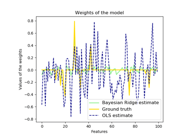

Bayesian Ridge Regression

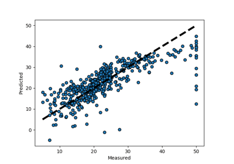

Plotting Cross-Validated Predictions

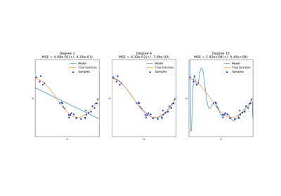

Underfitting vs. Overfitting

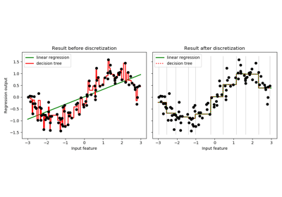

Using KBinsDiscretizer to discretize continuous features

© 2007–2018 The scikit-learn developers  
Licensed under the 3-clause BSD License.  
http://scikit-learn.org/stable/modules/generated/sklearn.linear_model.LinearRegression.html